# Project_Movies_Dataset

PROJECT MOVIE DATA ANALYSIS

Author:THIORO FALL

```
Table of Contents

 Introduction
 Data Wrangling
 Exploratory Data Analysis
 Conclusions
```

```
Introduction
```

In this project, we will be analyzing dataset that contains informations from The Movie Database(TMDb). What can we say about a movie after it is released. Here are the steps we will be taking: Step 1:the following questions will be the focus of my analysis: -what is the relationship between popularity, budget, revenue, profit and vote count? which genres of movies are the most released over the year? -which director directed most movies? -which actor and actress casted in most movies? which genre of movies are the most popular?  
-which movies(genre and original title) are the highest and lowest revenue? -which movies(genre and original title) are the highest and lowest budget? -Which movie(genre and original title) is the most successfull? Step 2:data wrangling We are going to load and assess the data; then, we will make some modifications to ensure that our data is clean and ready for analysis. Step3: data exploration We will look for relationship, correlation , and patterns regarding the dataset by dranwing some visualizations. Step 4: conclusions and limitations We will summarize our findings and terminate by mentionning our limitations during our analysis. We will be using python libraries such as pandas, NumPy, matplotlib and seaborn.

```python
# import the python packages I will need for my analysis
import pandas as pd
import numpy as np
import matplotlib.pyplot as plt
import seaborn as sns
%matplotlib inline
```

```
Data wrangling
```

In this step, we will first load our data; a csv speadsheet is provided by Udacity. We will be looking for data types, for missing and duplicates data. Also, to get a sense for whether a column has problems, we will use .unique() function to look at all its values.

```python
# Read the csv file with panda
df=pd.read_csv('tmdb-movies.csv')
df.head()
```

|  | id | imdb_id | popularity | budget | revenue | original_title | cast | homepage | director | tagline | ... | overview | runtime | genres | production_companies | release_date | vote_count | vote_average | release_year | budget_adj | revenue_adj |
| --- | --- | --- | --- | --- | --- | --- | --- | --- | --- | --- | --- | --- | --- | --- | --- | --- | --- | --- | --- | --- | --- |
| 0 | 135397 | tt0369610 | 32.985763 | 150000000 | 1513528810 | Jurassic World | Chris Pratt\|Bryce Dallas Howard\|Irrfan Khan\|Vi... | http://www.jurassicworld.com/ | Colin Trevorrow | The park is open. | ... | Twenty-two years after the events of Jurassic ... | 124 | Action\|Adventure\|Science Fiction\|Thriller | Universal Studios\|Amblin Entertainment\|Legenda... | 6/9/15 | 5562 | 6.5 | 2015 | 1.379999e+08 | 1.392446e+09 |
| 1 | 76341 | tt1392190 | 28.419936 | 150000000 | 378436354 | Mad Max: Fury Road | Tom Hardy\|Charlize Theron\|Hugh Keays-Byrne\|Nic... | http://www.madmaxmovie.com/ | George Miller | What a Lovely Day. | ... | An apocalyptic story set in the furthest reach... | 120 | Action\|Adventure\|Science Fiction\|Thriller | Village Roadshow Pictures\|Kennedy Miller Produ... | 5/13/15 | 6185 | 7.1 | 2015 | 1.379999e+08 | 3.481613e+08 |
| 2 | 262500 | tt2908446 | 13.112507 | 110000000 | 295238201 | Insurgent | Shailene Woodley\|Theo James\|Kate Winslet\|Ansel... | http://www.thedivergentseries.movie/#insurgent | Robert Schwentke | One Choice Can Destroy You | ... | Beatrice Prior must confront her inner demons ... | 119 | Adventure\|Science Fiction\|Thriller | Summit Entertainment\|Mandeville Films\|Red Wago... | 3/18/15 | 2480 | 6.3 | 2015 | 1.012000e+08 | 2.716190e+08 |
| 3 | 140607 | tt2488496 | 11.173104 | 200000000 | 2068178225 | Star Wars: The Force Awakens | Harrison Ford\|Mark Hamill\|Carrie Fisher\|Adam D... | http://www.starwars.com/films/star-wars-episod... | J.J. Abrams | Every generation has a story. | ... | Thirty years after defeating the Galactic Empi... | 136 | Action\|Adventure\|Science Fiction\|Fantasy | Lucasfilm\|Truenorth Productions\|Bad Robot | 12/15/15 | 5292 | 7.5 | 2015 | 1.839999e+08 | 1.902723e+09 |
| 4 | 168259 | tt2820852 | 9.335014 | 190000000 | 1506249360 | Furious 7 | Vin Diesel\|Paul Walker\|Jason Statham\|Michelle ... | http://www.furious7.com/ | James Wan | Vengeance Hits Home | ... | Deckard Shaw seeks revenge against Dominic Tor... | 137 | Action\|Crime\|Thriller | Universal Pictures\|Original Film\|Media Rights ... | 4/1/15 | 2947 | 7.3 | 2015 | 1.747999e+08 | 1.385749e+09 |

5 rows × 21 columns

```python
# Assess number of rows and columns of our dataset
df.shape
```

```
(10866, 21)
```

```python
# Assess summary of our dataset, including datatypes, missing data
df.info()
```

```
<class 'pandas.core.frame.DataFrame'>
RangeIndex: 10866 entries, 0 to 10865
Data columns (total 21 columns):
id                      10866 non-null int64
imdb_id                 10856 non-null object
popularity              10866 non-null float64
budget                  10866 non-null int64
revenue                 10866 non-null int64
original_title          10866 non-null object
cast                    10790 non-null object
homepage                2936 non-null object
director                10822 non-null object
tagline                 8042 non-null object
keywords                9373 non-null object
overview                10862 non-null object
runtime                 10866 non-null int64
genres                  10843 non-null object
production_companies    9836 non-null object
release_date            10866 non-null object
vote_count              10866 non-null int64
vote_average            10866 non-null float64
release_year            10866 non-null int64
budget_adj              10866 non-null float64
revenue_adj             10866 non-null float64
dtypes: float64(4), int64(6), object(11)
memory usage: 1.7+ MB
```

```python
df.isnull().sum()
```

```
id                         0
imdb_id                   10
popularity                 0
budget                     0
revenue                    0
original_title             0
cast                      76
homepage                7930
director                  44
tagline                 2824
keywords                1493
overview                   4
runtime                    0
genres                    23
production_companies    1030
release_date               0
vote_count                 0
vote_average               0
release_year               0
budget_adj                 0
revenue_adj                0
dtype: int64
```

There are 10866 rows and 21 columns. We also find missing records for many columns. But, I plan to remove most of them since they aren't directly relevant to our questions. We will be revisit missing data once the dataset is trimmed. Next, we wil assess the statistics for the columns.

```python
# Assess statistics for each columns
df.describe()
```

|  | id | popularity | budget | revenue | runtime | vote_count | vote_average | release_year | budget_adj | revenue_adj |
| --- | --- | --- | --- | --- | --- | --- | --- | --- | --- | --- |
| count | 10866.000000 | 10866.000000 | 1.086600e+04 | 1.086600e+04 | 10866.000000 | 10866.000000 | 10866.000000 | 10866.000000 | 1.086600e+04 | 1.086600e+04 |
| mean | 66064.177434 | 0.646441 | 1.462570e+07 | 3.982332e+07 | 102.070863 | 217.389748 | 5.974922 | 2001.322658 | 1.755104e+07 | 5.136436e+07 |
| std | 92130.136561 | 1.000185 | 3.091321e+07 | 1.170035e+08 | 31.381405 | 575.619058 | 0.935142 | 12.812941 | 3.430616e+07 | 1.446325e+08 |
| min | 5.000000 | 0.000065 | 0.000000e+00 | 0.000000e+00 | 0.000000 | 10.000000 | 1.500000 | 1960.000000 | 0.000000e+00 | 0.000000e+00 |
| 25% | 10596.250000 | 0.207583 | 0.000000e+00 | 0.000000e+00 | 90.000000 | 17.000000 | 5.400000 | 1995.000000 | 0.000000e+00 | 0.000000e+00 |
| 50% | 20669.000000 | 0.383856 | 0.000000e+00 | 0.000000e+00 | 99.000000 | 38.000000 | 6.000000 | 2006.000000 | 0.000000e+00 | 0.000000e+00 |
| 75% | 75610.000000 | 0.713817 | 1.500000e+07 | 2.400000e+07 | 111.000000 | 145.750000 | 6.600000 | 2011.000000 | 2.085325e+07 | 3.369710e+07 |
| max | 417859.000000 | 32.985763 | 4.250000e+08 | 2.781506e+09 | 900.000000 | 9767.000000 | 9.200000 | 2015.000000 | 4.250000e+08 | 2.827124e+09 |

```python
# I am going to drop: imdb id, homepage, production_companies, tagline, keywords,overview, runtime, release_date, vote_average, budget adj and revenue adj.
df.drop(['imdb_id', 'production_companies', 'homepage', 'tagline', 'keywords','overview', 'runtime', 'release_date','vote_average', 'budget_adj', 'revenue_adj'], axis=1, inplace=True)
```

```python
df.head()
```

|  | id | popularity | budget | revenue | original_title | cast | director | genres | vote_count | release_year |
| --- | --- | --- | --- | --- | --- | --- | --- | --- | --- | --- |
| 0 | 135397 | 32.985763 | 150000000 | 1513528810 | Jurassic World | Chris Pratt\|Bryce Dallas Howard\|Irrfan Khan\|Vi... | Colin Trevorrow | Action\|Adventure\|Science Fiction\|Thriller | 5562 | 2015 |
| 1 | 76341 | 28.419936 | 150000000 | 378436354 | Mad Max: Fury Road | Tom Hardy\|Charlize Theron\|Hugh Keays-Byrne\|Nic... | George Miller | Action\|Adventure\|Science Fiction\|Thriller | 6185 | 2015 |
| 2 | 262500 | 13.112507 | 110000000 | 295238201 | Insurgent | Shailene Woodley\|Theo James\|Kate Winslet\|Ansel... | Robert Schwentke | Adventure\|Science Fiction\|Thriller | 2480 | 2015 |
| 3 | 140607 | 11.173104 | 200000000 | 2068178225 | Star Wars: The Force Awakens | Harrison Ford\|Mark Hamill\|Carrie Fisher\|Adam D... | J.J. Abrams | Action\|Adventure\|Science Fiction\|Fantasy | 5292 | 2015 |
| 4 | 168259 | 9.335014 | 190000000 | 1506249360 | Furious 7 | Vin Diesel\|Paul Walker\|Jason Statham\|Michelle ... | James Wan | Action\|Crime\|Thriller | 2947 | 2015 |

```python
df.info()
```

```
<class 'pandas.core.frame.DataFrame'>
RangeIndex: 10866 entries, 0 to 10865
Data columns (total 10 columns):
id                10866 non-null int64
popularity        10866 non-null float64
budget            10866 non-null int64
revenue           10866 non-null int64
original_title    10866 non-null object
cast              10790 non-null object
director          10822 non-null object
genres            10843 non-null object
vote_count        10866 non-null int64
release_year      10866 non-null int64
dtypes: float64(1), int64(5), object(4)
memory usage: 849.0+ KB
```

```python
#df.info()
```

```python
# Assess for duplicate records
df.duplicated().sum()
```

```
1
```

There is only one duplicate and we are going to drop that row and will then check if there is any missing values.

```python
df.drop_duplicates(inplace=True)
```

```python
df.duplicated().sum()
```

```
0
```

```python
df.shape
```

```
(10865, 10)
```

Now, we don't have any more duplicates. Next, we will assess if there are any missing values.

```python
df.isnull().sum()
```

```
id                 0
popularity         0
budget             0
revenue            0
original_title     0
cast              76
director          44
genres            23
vote_count         0
release_year       0
dtype: int64
```

Now we know there are missing values, let's view the rows with missing information to see if it is okay to drop them. We would like to order by release_year to see if it is okay to drop them.

```python
df[df.isnull().any(axis=1)].sort_values(['release_year'], ascending=True)
```

|  | id | popularity | budget | revenue | original_title | cast | director | genres | vote_count | release_year |
| --- | --- | --- | --- | --- | --- | --- | --- | --- | --- | --- |
| 10434 | 48784 | 0.146906 | 200 | 0 | Six Men Getting Sick | NaN | David Lynch | Animation | 16 | 1967 |
| 10426 | 34038 | 0.114034 | 0 | 0 | Magical Mystery Tour | John Lennon\|Paul McCartney\|George Harrison\|Rin... | NaN | Music | 15 | 1967 |
| 9755 | 48714 | 0.046272 | 0 | 0 | The Big Shave | NaN | Martin Scorsese | Drama | 12 | 1968 |
| 10754 | 3171 | 0.002757 | 0 | 0 | Bambi Meets Godzilla | NaN | Marv Newland | Animation\|Comedy | 12 | 1969 |
| 10659 | 4255 | 0.344172 | 5000 | 0 | The Party at Kitty and Stud's | Sylvester Stallone\|Henrietta Holm\|Nicholas War... | Morton Lewis | NaN | 10 | 1970 |
| 9799 | 48847 | 0.175008 | 0 | 0 | The Amputee | Catherine E. Coulson\|David Lynch | David Lynch | NaN | 11 | 1974 |
| 1385 | 20785 | 0.002457 | 0 | 0 | Emmet Otter's Jug-Band Christmas | NaN | Jim Henson | Drama\|Comedy\|Family | 10 | 1977 |
| 7905 | 13924 | 0.647261 | 0 | 0 | The Adventures of AndrÃ© and Wally B. | NaN | Alvy Ray Smith | Animation | 32 | 1984 |
| 6181 | 18729 | 0.000065 | 0 | 0 | North and South, Book I | Patrick Swayze\|Philip Casnoff\|Kirstie Alley\|Ge... | NaN | Drama\|History\|Western | 17 | 1985 |
| 10550 | 13925 | 0.306425 | 0 | 0 | Luxo Jr. | NaN | John Lasseter | Animation\|Family | 81 | 1986 |
| 9677 | 13926 | 0.253376 | 0 | 0 | Red's Dream | NaN | John Lasseter | Animation | 44 | 1987 |
| 9593 | 46188 | 0.001662 | 0 | 0 | Peter Pan | NaN | NaN | Action\|Adventure\|Animation\|Family\|Fantasy | 28 | 1988 |
| 9564 | 24348 | 0.168545 | 2500000 | 589244 | Powaqqatsi | NaN | Godfrey Reggio | Documentary\|Drama\|Music | 18 | 1988 |
| 9529 | 13927 | 0.236514 | 0 | 0 | Tin Toy | NaN | John Lasseter | Animation\|Family | 51 | 1988 |
| 9251 | 13928 | 0.471351 | 0 | 0 | Knick Knack | NaN | John Lasseter | Animation\|Family | 77 | 1989 |
| 9307 | 141859 | 0.094652 | 0 | 0 | Goldeneye | Charles Dance\|Phyllis Logan\|Patrick Ryecart\|La... | Don Boyd | NaN | 10 | 1989 |
| 8292 | 14002 | 0.521669 | 4000000 | 0 | Baraka | NaN | Ron Fricke | Documentary | 89 | 1992 |
| 10386 | 225804 | 0.118854 | 0 | 0 | The Making of 'The Nightmare Before Christmas' | Mike Belzer\|Tim Burton\|Bonita DeCarlo\|Greg Dyk... | NaN | Documentary | 15 | 1993 |
| 8234 | 56804 | 0.028874 | 0 | 0 | Viaggi di nozze | Carlo Verdone\|Claudia Gerini\|Veronica Pivetti\|... | Carlo Verdone | NaN | 44 | 1995 |
| 8614 | 65595 | 0.273934 | 0 | 0 | T2 3-D: Battle Across Time | Arnold Schwarzenegger\|Linda Hamilton\|Edward Fu... | James Cameron | NaN | 14 | 1996 |
| 5413 | 20378 | 0.324270 | 0 | 0 | The Brave Little Toaster to the Rescue | NaN | NaN | Animation\|Comedy\|Family | 11 | 1997 |
| 8824 | 48617 | 0.191631 | 0 | 0 | Father and Daughter | NaN | Michael Dudok de Wit | Animation\|Drama | 18 | 2000 |
| 8880 | 48868 | 0.032577 | 0 | 0 | The World of Stainboy | NaN | Tim Burton | Animation | 10 | 2000 |
| 8878 | 92208 | 0.038045 | 0 | 0 | Mom's Got a Date With a Vampire | Matt O'Leary\|Laura Vandervoort\|Myles Jeffrey\|C... | Steve Boyum | NaN | 16 | 2000 |
| 2853 | 57892 | 0.130018 | 0 | 0 | Vizontele | YÄ±lmaz ErdoÄŸan\|Demet Akbag\|Altan Erkekli\|Cem... | YÄ±lmaz ErdoÄŸan | NaN | 12 | 2001 |
| 4140 | 16636 | 0.164301 | 0 | 0 | Spellbound | NaN | Jeffrey Blitz | Documentary | 15 | 2002 |
| 4127 | 21925 | 0.193929 | 3000000 | 13308 | Naqoyqatsi | NaN | Godfrey Reggio | Documentary\|Drama\|Music\|Thriller | 20 | 2002 |
| 6530 | 168891 | 0.092724 | 0 | 0 | Saw Rebirth | Whit Anderson\|Stan Kirsch\|Jeff Shuter\|George W... | Jeff Shuter\|Daniel Viney | NaN | 24 | 2005 |
| 6514 | 98622 | 0.128484 | 0 | 0 | 9 | NaN | Shane Acker | Animation\|Fantasy | 49 | 2005 |
| 6374 | 13933 | 0.392879 | 0 | 0 | One Man Band | NaN | Mark Andrews\|Andrew Jimenez | Animation\|Family | 70 | 2005 |
| ... | ... | ... | ... | ... | ... | ... | ... | ... | ... | ... |
| 1190 | 250761 | 0.137962 | 0 | 0 | Last Days in Vietnam | NaN | Rory Kennedy | War\|Documentary | 20 | 2014 |
| 997 | 287663 | 0.330431 | 0 | 0 | Star Wars Rebels: Spark of Rebellion | Freddie Prinze Jr.\|Vanessa Marshall\|Steve Blum... | Steward Lee\|Steven G. Lee | NaN | 13 | 2014 |
| 1032 | 259910 | 0.291253 | 0 | 0 | Marvel Studios: Assembling a Universe | Robert Downey Jr.\|Chris Hemsworth\|Chris Evans\|... | NaN | TV Movie\|Documentary | 32 | 2014 |
| 1054 | 253675 | 0.269468 | 0 | 0 | Unlocking Sherlock | Benedict Cumberbatch\|Martin Freeman\|Steven Mof... | NaN | TV Movie\|Documentary | 11 | 2014 |
| 1088 | 169607 | 0.226028 | 0 | 1503616 | Finding Vivian Maier | NaN | John Maloof\|Charlie Siskel | Documentary | 70 | 2014 |
| 1173 | 261041 | 0.159037 | 0 | 0 | The Search for General Tso | NaN | Ian Cheney | Documentary | 14 | 2014 |
| 1177 | 269711 | 0.153047 | 0 | 0 | JohnnyExpress | NaN | Kyungmin Woo | Animation\|Comedy\|Science Fiction | 14 | 2014 |
| 1203 | 256561 | 0.119891 | 150000 | 0 | Free to Play | Benedict Lim\|Danil Ishutin\|Clinton Loomis | NaN | Documentary | 40 | 2014 |
| 1327 | 258614 | 0.003504 | 0 | 0 | Pantani: The Accidental Death of a Cyclist | NaN | James Erskine | Documentary | 11 | 2014 |
| 1236 | 250665 | 0.093062 | 0 | 0 | No No: A Dockumentary | NaN | Jeffrey Radice | Documentary | 13 | 2014 |
| 1241 | 296370 | 0.135376 | 0 | 0 | Dance-Off | Kathryn McCormick\|Shane Harper\|Finola Hughes\|C... | NaN | Romance\|Music\|Comedy | 18 | 2014 |
| 1256 | 299729 | 0.076280 | 0 | 0 | Banksy Does New York | NaN | Chris Moukarbel | Documentary | 22 | 2014 |
| 1288 | 301235 | 0.038364 | 0 | 0 | Top Gear: The Perfect Road Trip 2 | Jeremy Clarkson\|Richard Hammond | NaN | Documentary | 12 | 2014 |
| 1315 | 250745 | 0.008000 | 0 | 0 | Happy Valley | NaN | Amir Bar-Lev | Documentary | 14 | 2014 |
| 1316 | 245158 | 0.007622 | 0 | 0 | Kids for Cash | NaN | Robert May | Documentary\|Thriller | 12 | 2014 |
| 1319 | 320420 | 0.005844 | 0 | 0 | Love Me | NaN | Jonathon Narducci | Documentary | 13 | 2014 |
| 1326 | 250668 | 0.023872 | 0 | 0 | Rich Hill | NaN | Tracy Droz Tragos\|Andrew Droz Palermo | Documentary | 14 | 2014 |
| 1208 | 282297 | 0.116190 | 117 | 0 | Cowspiracy: The Sustainability Secret | NaN | Kip Anderson\|Keegan Kuhn | Documentary | 66 | 2014 |
| 424 | 363869 | 0.244648 | 0 | 0 | Belli di papÃ | Diego Abatantuono\|Matilde Gioli\|Andrea Pisani\|... | Guido Chiesa | NaN | 21 | 2015 |
| 441 | 355020 | 0.220751 | 0 | 0 | Winter on Fire: Ukraine's Fight for Freedom | NaN | Evgeny Afineevsky | Documentary | 37 | 2015 |
| 465 | 321109 | 0.201696 | 0 | 0 | Bitter Lake | NaN | Adam Curtis | Documentary | 19 | 2015 |
| 532 | 320996 | 0.126594 | 0 | 0 | Iliza Shlesinger: Freezing Hot | Iliza Shlesinger | NaN | Comedy | 14 | 2015 |
| 536 | 333350 | 0.122543 | 0 | 0 | A Faster Horse | NaN | David Gelb | Documentary | 12 | 2015 |
| 587 | 319091 | 0.062536 | 0 | 0 | The Hunting Ground | NaN | Kirby Dick | Documentary | 39 | 2015 |
| 548 | 355131 | 0.108072 | 0 | 0 | Sense8: Creating the World | Tuppence Middleton\|Bae Doona \|Brian J. Smith\|A... | NaN | Documentary\|Science Fiction | 12 | 2015 |
| 556 | 321160 | 0.100910 | 0 | 0 | With This Ring | Regina Hall\|Jill Scott\|Eve\|Brooklyn Sudano\|Dei... | NaN | Comedy\|Romance | 14 | 2015 |
| 600 | 332479 | 0.047256 | 0 | 0 | Star Wars: TIE Fighter | NaN | Paul Johnson | Science Fiction\|Action\|Animation | 29 | 2015 |
| 620 | 361043 | 0.129696 | 0 | 0 | All Hallows' Eve 2 | NaN | Antonio Padovan\|Bryan Norton\|Marc Roussel\|Ryan... | NaN | 13 | 2015 |
| 538 | 224972 | 0.114264 | 0 | 0 | The Mask You Live In | NaN | Jennifer Siebel Newsom | Documentary | 11 | 2015 |
| 371 | 345637 | 0.422901 | 0 | 0 | Sanjay's Super Team | NaN | Sanjay Patel | Animation | 47 | 2015 |

134 rows × 10 columns

The NaN missing informations are non numerical data; we are confortable dropping them.

```python
df.dropna(inplace=True)
```

```python
#Checking if NaN data were drop
df.isnull().sum()
```

```
id                0
popularity        0
budget            0
revenue           0
original_title    0
cast              0
director          0
genres            0
vote_count        0
release_year      0
dtype: int64
```

```python
df.head()
```

|  | id | popularity | budget | revenue | original_title | cast | director | genres | vote_count | release_year |
| --- | --- | --- | --- | --- | --- | --- | --- | --- | --- | --- |
| 0 | 135397 | 32.985763 | 150000000 | 1513528810 | Jurassic World | Chris Pratt\|Bryce Dallas Howard\|Irrfan Khan\|Vi... | Colin Trevorrow | Action\|Adventure\|Science Fiction\|Thriller | 5562 | 2015 |
| 1 | 76341 | 28.419936 | 150000000 | 378436354 | Mad Max: Fury Road | Tom Hardy\|Charlize Theron\|Hugh Keays-Byrne\|Nic... | George Miller | Action\|Adventure\|Science Fiction\|Thriller | 6185 | 2015 |
| 2 | 262500 | 13.112507 | 110000000 | 295238201 | Insurgent | Shailene Woodley\|Theo James\|Kate Winslet\|Ansel... | Robert Schwentke | Adventure\|Science Fiction\|Thriller | 2480 | 2015 |
| 3 | 140607 | 11.173104 | 200000000 | 2068178225 | Star Wars: The Force Awakens | Harrison Ford\|Mark Hamill\|Carrie Fisher\|Adam D... | J.J. Abrams | Action\|Adventure\|Science Fiction\|Fantasy | 5292 | 2015 |
| 4 | 168259 | 9.335014 | 190000000 | 1506249360 | Furious 7 | Vin Diesel\|Paul Walker\|Jason Statham\|Michelle ... | James Wan | Action\|Crime\|Thriller | 2947 | 2015 |

```python
df.info()
```

```
<class 'pandas.core.frame.DataFrame'>
Int64Index: 10731 entries, 0 to 10865
Data columns (total 10 columns):
id                10731 non-null int64
popularity        10731 non-null float64
budget            10731 non-null int64
revenue           10731 non-null int64
original_title    10731 non-null object
cast              10731 non-null object
director          10731 non-null object
genres            10731 non-null object
vote_count        10731 non-null int64
release_year      10731 non-null int64
dtypes: float64(1), int64(5), object(4)
memory usage: 922.2+ KB
```

```python
df.shape
```

```
(10731, 10)
```

```python
df['profit']=df['revenue']-df['budget']
```

```python
df.info()
```

```
<class 'pandas.core.frame.DataFrame'>
Int64Index: 10731 entries, 0 to 10865
Data columns (total 11 columns):
id                10731 non-null int64
popularity        10731 non-null float64
budget            10731 non-null int64
revenue           10731 non-null int64
original_title    10731 non-null object
cast              10731 non-null object
director          10731 non-null object
genres            10731 non-null object
vote_count        10731 non-null int64
release_year      10731 non-null int64
profit            10731 non-null int64
dtypes: float64(1), int64(6), object(4)
memory usage: 1006.0+ KB
```

```python
#make sure no negative numbers for profit
df.loc[df['profit'] < 0, 'profit'] = 0
```

```python
df.head()
```

|  | id | popularity | budget | revenue | original_title | cast | director | genres | vote_count | release_year | profit |
| --- | --- | --- | --- | --- | --- | --- | --- | --- | --- | --- | --- |
| 0 | 135397 | 32.985763 | 150000000 | 1513528810 | Jurassic World | Chris Pratt\|Bryce Dallas Howard\|Irrfan Khan\|Vi... | Colin Trevorrow | Action\|Adventure\|Science Fiction\|Thriller | 5562 | 2015 | 1363528810 |
| 1 | 76341 | 28.419936 | 150000000 | 378436354 | Mad Max: Fury Road | Tom Hardy\|Charlize Theron\|Hugh Keays-Byrne\|Nic... | George Miller | Action\|Adventure\|Science Fiction\|Thriller | 6185 | 2015 | 228436354 |
| 2 | 262500 | 13.112507 | 110000000 | 295238201 | Insurgent | Shailene Woodley\|Theo James\|Kate Winslet\|Ansel... | Robert Schwentke | Adventure\|Science Fiction\|Thriller | 2480 | 2015 | 185238201 |
| 3 | 140607 | 11.173104 | 200000000 | 2068178225 | Star Wars: The Force Awakens | Harrison Ford\|Mark Hamill\|Carrie Fisher\|Adam D... | J.J. Abrams | Action\|Adventure\|Science Fiction\|Fantasy | 5292 | 2015 | 1868178225 |
| 4 | 168259 | 9.335014 | 190000000 | 1506249360 | Furious 7 | Vin Diesel\|Paul Walker\|Jason Statham\|Michelle ... | James Wan | Action\|Crime\|Thriller | 2947 | 2015 | 1316249360 |

```python
df['budget'].unique()
```

```
array([150000000, 110000000, 200000000, 190000000, 135000000, 155000000,
       108000000,  74000000, 175000000, 245000000, 176000003,  15000000,
        88000000, 280000000,  44000000,  48000000, 130000000,  95000000,
       160000000,  30000000,  40000000,  28000000,  68000000,  81000000,
        20000000,  61000000,         0,  49000000,  29000000,  58000000,
         6000000,  50000000,  11000000,  90000000,  75000000,  25000000,
        10000000,  12000000,   4000000,  11800000,  35000000,  55000000,
        60000000, 105000000,  26000000,  70000000, 120000001,   3500000,
        65000000,  50100000, 100000000,  13000000,  99000000,   2500000,
        34000000,  80000000,  17000000,  31000000,   5000000,  64000000,
        11930000,   8500000,  23000000,  53000000,   8900000,    700000,
        14800000,  19500000,   1000000,   8000000,   1800000,   2000000,
        18000000,    630019,  14000000,  37000000,   7000000,   3000000,
         9600000,   2240000,   3300000,    100000,  21000000,   5300000,
         9000000,    447524,   1950000,   4400000,  27000000,    500000,
```

[output cut: 78 more lines]

```python
df['revenue'].unique()
```

```
array([1513528810,  378436354,  295238201, ...,     321952,   78000000,
         33736689], dtype=int64)
```

Now let's see how many zero value we have for budget, revenue and profit

```python
(df['budget']==0).sum()
```

```
5578
```

```python
(df['revenue']==0).sum()
```

```
5888
```

```python
(df['profit']==0).sum()
```

```
6961
```

```python
df['budget'].replace(0,(df['budget']!=0).mean(), inplace=True)
```

```python
df['revenue'].replace(0,(df['revenue']!=0).mean(), inplace=True)
```

```python
df['profit'].replace(0,(df['profit']!=0).mean(), inplace=True)
```

```python
(df['budget']==0).sum()
```

```
0
```

```python
(df['revenue']==0).sum()
```

```
0
```

```python
(df['profit']==0).sum()
```

```
0
```

```python
df.shape
```

```
(10731, 11)
```

```python
df.info()
```

```
<class 'pandas.core.frame.DataFrame'>
Int64Index: 10731 entries, 0 to 10865
Data columns (total 11 columns):
id                10731 non-null int64
popularity        10731 non-null float64
budget            10731 non-null float64
revenue           10731 non-null float64
original_title    10731 non-null object
cast              10731 non-null object
director          10731 non-null object
genres            10731 non-null object
vote_count        10731 non-null int64
release_year      10731 non-null int64
profit            10731 non-null float64
dtypes: float64(4), int64(3), object(4)
memory usage: 1006.0+ KB
```

Now, we do have some issues with columns genres and cast. Some rows have a combination of genres and cast. I'll create separate dataframes for each: genres and cast in case we need the original df. First, we are going to split up the genres column so we can tally each genre individually. Next, I'll remove the 'genres' column (with multiple values) and replace it with a 'genre' column (with single values). Then I'll make sure that there is a new row for each genre (stacked), so there will be multiple rows with the same original_title.

```python
df_split_genre = df.copy()
split_genre = df_split_genre['genres'].str.split('|').apply(pd.Series, 1
).stack().reset_index(level=1, drop=True)
split_genre.name = 'genre_split'
df_split_genre = df_split_genre.drop(['genres'], axis=1).join(split_genre)
```

The genres column now appear to be split up and stacked, let's check to make sure that the new genre column contains only single value.

```python
df_split_genre['genre_split'].unique()
```

```
array(['Action', 'Adventure', 'Science Fiction', 'Thriller', 'Fantasy',
       'Crime', 'Western', 'Drama', 'Family', 'Animation', 'Comedy',
       'Mystery', 'Romance', 'War', 'History', 'Music', 'Horror',
       'Documentary', 'TV Movie', 'Foreign'], dtype=object)
```

Now, let's clean our new dataframe df_split_genre

```python
df_split_genre.info()
```

```
<class 'pandas.core.frame.DataFrame'>
Int64Index: 26753 entries, 0 to 10865
Data columns (total 11 columns):
id                26753 non-null int64
popularity        26753 non-null float64
budget            26753 non-null float64
revenue           26753 non-null float64
original_title    26753 non-null object
cast              26753 non-null object
director          26753 non-null object
vote_count        26753 non-null int64
release_year      26753 non-null int64
profit            26753 non-null float64
genre_split       26753 non-null object
dtypes: float64(4), int64(3), object(4)
memory usage: 2.4+ MB
```

```python
df_split_genre.shape
```

```
(26753, 11)
```

```python
sum(df_split_genre.duplicated())
```

```
0
```

```python
df_split_genre.isnull().sum()
```

```
id                0
popularity        0
budget            0
revenue           0
original_title    0
cast              0
director          0
vote_count        0
release_year      0
profit            0
genre_split       0
dtype: int64
```

Our new dataframe df_split_genre has 26753 rows and 11 columns.there is no duplicates or missing values. Now, let's see how many '0' do we have for each columns:budget and revenue.

```python
(df_split_genre['budget']==0).sum()
```

```
0
```

```python
(df_split_genre['revenue']==0).sum()
```

```
0
```

```python
(df_split_genre['profit']==0).sum()
```

```
0
```

```python
df_split_genre.head()
```

|  | id | popularity | budget | revenue | original_title | cast | director | vote_count | release_year | profit | genre_split |
| --- | --- | --- | --- | --- | --- | --- | --- | --- | --- | --- | --- |
| 0 | 135397 | 32.985763 | 150000000.0 | 1.513529e+09 | Jurassic World | Chris Pratt\|Bryce Dallas Howard\|Irrfan Khan\|Vi... | Colin Trevorrow | 5562 | 2015 | 1.363529e+09 | Action |
| 0 | 135397 | 32.985763 | 150000000.0 | 1.513529e+09 | Jurassic World | Chris Pratt\|Bryce Dallas Howard\|Irrfan Khan\|Vi... | Colin Trevorrow | 5562 | 2015 | 1.363529e+09 | Adventure |
| 0 | 135397 | 32.985763 | 150000000.0 | 1.513529e+09 | Jurassic World | Chris Pratt\|Bryce Dallas Howard\|Irrfan Khan\|Vi... | Colin Trevorrow | 5562 | 2015 | 1.363529e+09 | Science Fiction |
| 0 | 135397 | 32.985763 | 150000000.0 | 1.513529e+09 | Jurassic World | Chris Pratt\|Bryce Dallas Howard\|Irrfan Khan\|Vi... | Colin Trevorrow | 5562 | 2015 | 1.363529e+09 | Thriller |
| 1 | 76341 | 28.419936 | 150000000.0 | 3.784364e+08 | Mad Max: Fury Road | Tom Hardy\|Charlize Theron\|Hugh Keays-Byrne\|Nic... | George Miller | 6185 | 2015 | 2.284364e+08 | Action |

For now, we have two clean dataframes:df and df_split_genre. We are going to do the same thing with cast.

```python
df_split_cast = df.copy()
split_cast = df_split_cast['cast'].str.split('|').apply(pd.Series, 1
).stack().reset_index(level=1, drop=True)
split_cast.name = 'cast_split'
df_split_cast = df_split_cast.drop(['cast'], axis=1).join(split_cast)
```

```python
df_split_cast.info()
df_split_cast.shape
sum(df_split_cast.duplicated())
df_split_cast.isnull().sum()
```

```
<class 'pandas.core.frame.DataFrame'>
Int64Index: 52334 entries, 0 to 10865
Data columns (total 11 columns):
id                52334 non-null int64
popularity        52334 non-null float64
budget            52334 non-null float64
revenue           52334 non-null float64
original_title    52334 non-null object
director          52334 non-null object
genres            52334 non-null object
vote_count        52334 non-null int64
release_year      52334 non-null int64
profit            52334 non-null float64
cast_split        52334 non-null object
dtypes: float64(4), int64(3), object(4)
memory usage: 4.8+ MB
```

```
id                0
popularity        0
budget            0
revenue           0
original_title    0
director          0
genres            0
vote_count        0
release_year      0
profit            0
cast_split        0
dtype: int64
```

```python
(df_split_cast['budget']==0).sum()
```

```
0
```

```python
(df_split_cast['revenue']==0).sum()
```

```
0
```

```python
(df_split_cast['profit']==0).sum()
```

```
0
```

For now, we have three clean dataframes: df, df_split_genre and df_split_cast. We are going to save them below:

```python
df.to_csv('tmbd-movies-clean.csv', index=False)
df_split_genre.to_csv('tmbd-movies-genre.csv', index=False)
df_split_cast.to_csv('tmbd-movies-cast.csv', index=False)
```

Now, let's move on to the next step with is the exploratory data analysis.

```
Exploratory Data Analysis
```

Now that we've trimmed and cleaned our data, let's move on to the exploration. In this section, we'll compute statistics and create visualizations with the goal of addressing the research questions that we posed in the Introduction section. Let's first view all columns with numerical data with a histogram:

For df.to_csv('tmbd-movies-clean.csv', index=False)

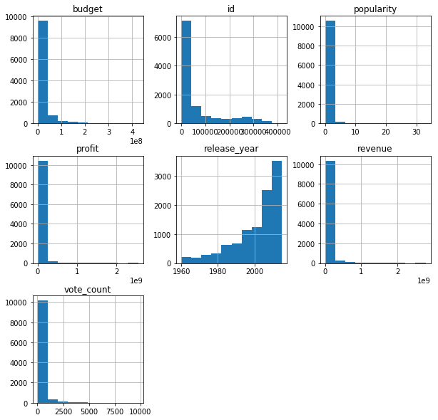

```python
# histogram of the whole new dataset
df.hist(figsize=(10,10));
```

The histogram of budget, id, popularity, profit, revenue and vote_count are very skewed to the right. However release year is skeded to the left. Instead of using hist, let me try to get a quick insight into the relationship among numerical variables with scatter plots.

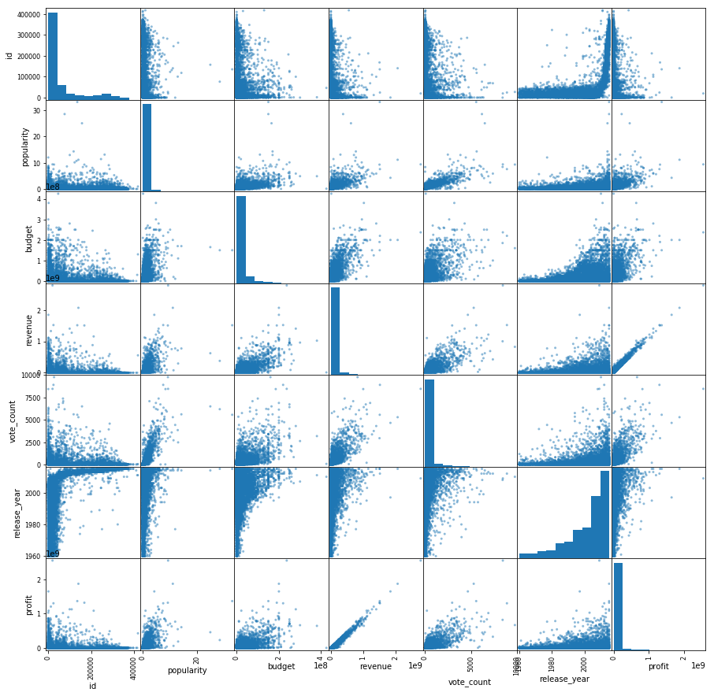

```python
pd.plotting.scatter_matrix(df,figsize=(15,15));
```

Now, which variables is associated with highest revenue? Let's do the scatter plots of revenue vs budget, popularity and profit.

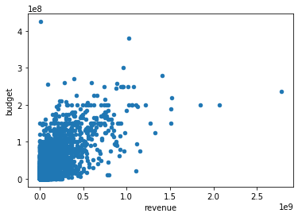

```python
df.plot(x='revenue', y='budget', kind='scatter');
```

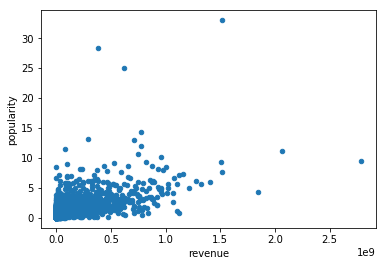

```python
df.plot(x='revenue', y='popularity', kind='scatter');
```

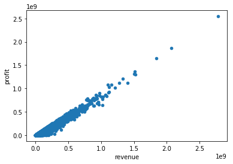

```python
df.plot(x='revenue', y='profit', kind='scatter');
```

At first glance, revenue and profits are positively correlated. Now let's see which directors directed most movies. We will be look at the top 10.

```python
df1=df['director'].value_counts()
df1.head(10)
```

```
Woody Allen          45
Clint Eastwood       34
Steven Spielberg     29
Martin Scorsese      28
Ridley Scott         23
Steven Soderbergh    22
Ron Howard           22
Joel Schumacher      21
Brian De Palma       20
Wes Craven           19
Name: director, dtype: int64
```

Woody Allen produced the highest number of movies. Let's check the visualization:

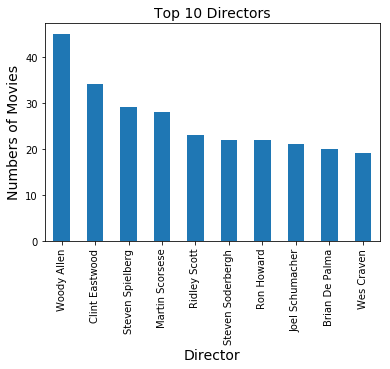

```python
df1=df['director'].value_counts()
df1.head(10).plot(kind='bar')
plt.title('Top 10 Directors', fontsize=14)
plt.xlabel('Director', fontsize=14)
plt.ylabel('Numbers of Movies', fontsize=14)
plt.show();
```

Now we know that Woody Allen has directed the most movies, let us find out about the actor or actress who have been cast the most movies.

```python
df2=df_split_cast['cast_split'].value_counts()
df2.head(10)
```

```
Robert De Niro       72
Samuel L. Jackson    71
Bruce Willis         62
Nicolas Cage         61
Michael Caine        53
Robin Williams       51
John Cusack          50
John Goodman         49
Morgan Freeman       49
Liam Neeson          48
Name: cast_split, dtype: int64
```

Robert De Niro and Samuel L. Jackson are the actors who cast the most movies.Let's do the visualization for the top 10 casts

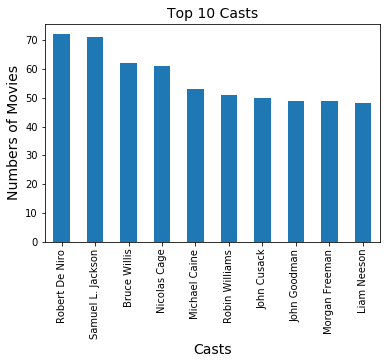

```python
df2=df_split_cast['cast_split'].value_counts()
df2.head(10).plot(kind='bar')
plt.title('Top 10 Casts', fontsize=14)
plt.xlabel('Casts', fontsize=14)
plt.ylabel('Numbers of Movies', fontsize=14)
plt.show();
```

Now let's see which genres of movies are most popular? We will be using: df_split_genre.to_csv('tmbd-movies-genre.csv', index=False) We are going to use the value_count function which returns the counts in order by size.

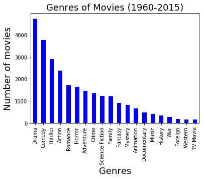

```python
df_split_genre['genre_split'].value_counts().plot(kind='bar', color='b');
plt.title('Genres of Movies (1960-2015)', fontsize=18)
plt.xlabel('Genres', fontsize=18)
plt.ylabel('Number of movies', fontsize=18);
```

Drama and comedy came on top. Let's also do the visualization with pie

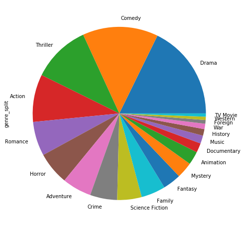

```python
df_split_genre['genre_split'].value_counts().plot(kind='pie', figsize=(8,8))
```

Drama, Comedy, Thriller, and Action are the most popular genres in general. The pie chart is a better visual since we can assess that these top 4 genres make up about 50% of all movies. TV Movies, Westerns, and Foreigns are the least popular genres.

Next, I am going to look up the highest records for revenue, in order to know the information about one of the best genres of movies.

```python
df.loc[df['revenue'].idxmax()]
```

```
id                                                            19995
popularity                                                  9.43277
budget                                                     2.37e+08
revenue                                                 2.78151e+09
original_title                                               Avatar
cast              Sam Worthington|Zoe Saldana|Sigourney Weaver|S...
director                                              James Cameron
genres                     Action|Adventure|Fantasy|Science Fiction
vote_count                                                     8458
release_year                                                   2009
profit                                                  2.54451e+09
Name: 1386, dtype: object
```

```python
df_split_genre.loc[df['revenue'].idxmax()]
```

|  | id | popularity | budget | revenue | original_title | cast | director | vote_count | release_year | profit | genre_split |
| --- | --- | --- | --- | --- | --- | --- | --- | --- | --- | --- | --- |
| 1386 | 19995 | 9.432768 | 237000000.0 | 2.781506e+09 | Avatar | Sam Worthington\|Zoe Saldana\|Sigourney Weaver\|S... | James Cameron | 8458 | 2009 | 2.544506e+09 | Action |
| 1386 | 19995 | 9.432768 | 237000000.0 | 2.781506e+09 | Avatar | Sam Worthington\|Zoe Saldana\|Sigourney Weaver\|S... | James Cameron | 8458 | 2009 | 2.544506e+09 | Adventure |
| 1386 | 19995 | 9.432768 | 237000000.0 | 2.781506e+09 | Avatar | Sam Worthington\|Zoe Saldana\|Sigourney Weaver\|S... | James Cameron | 8458 | 2009 | 2.544506e+09 | Fantasy |
| 1386 | 19995 | 9.432768 | 237000000.0 | 2.781506e+09 | Avatar | Sam Worthington\|Zoe Saldana\|Sigourney Weaver\|S... | James Cameron | 8458 | 2009 | 2.544506e+09 | Science Fiction |

```python
df_split_cast.loc[df['revenue'].idxmax()]
```

|  | id | popularity | budget | revenue | original_title | director | genres | vote_count | release_year | profit | cast_split |
| --- | --- | --- | --- | --- | --- | --- | --- | --- | --- | --- | --- |
| 1386 | 19995 | 9.432768 | 237000000.0 | 2.781506e+09 | Avatar | James Cameron | Action\|Adventure\|Fantasy\|Science Fiction | 8458 | 2009 | 2.544506e+09 | Sam Worthington |
| 1386 | 19995 | 9.432768 | 237000000.0 | 2.781506e+09 | Avatar | James Cameron | Action\|Adventure\|Fantasy\|Science Fiction | 8458 | 2009 | 2.544506e+09 | Zoe Saldana |
| 1386 | 19995 | 9.432768 | 237000000.0 | 2.781506e+09 | Avatar | James Cameron | Action\|Adventure\|Fantasy\|Science Fiction | 8458 | 2009 | 2.544506e+09 | Sigourney Weaver |
| 1386 | 19995 | 9.432768 | 237000000.0 | 2.781506e+09 | Avatar | James Cameron | Action\|Adventure\|Fantasy\|Science Fiction | 8458 | 2009 | 2.544506e+09 | Stephen Lang |
| 1386 | 19995 | 9.432768 | 237000000.0 | 2.781506e+09 | Avatar | James Cameron | Action\|Adventure\|Fantasy\|Science Fiction | 8458 | 2009 | 2.544506e+09 | Michelle Rodriguez |

The movie 'Avatar', under the director James Cameron has the highest revenue in 2009. The movie 'Avatar' is under the category genres Action, Adventure, Fantasy and Science Fiction. Also by using the three drataframe defined above we have the same result, just some repetition.Let's check the movie with the lowest revenue:

```python
df.loc[df['revenue'].idxmin()]
```

```
id                                                           265208
popularity                                                  2.93234
budget                                                        3e+07
revenue                                                    0.451309
original_title                                            Wild Card
cast              Jason Statham|Michael Angarano|Milo Ventimigli...
director                                                 Simon West
genres                                         Thriller|Crime|Drama
vote_count                                                      481
release_year                                                   2015
profit                                                     0.351319
Name: 48, dtype: object
```

The movie 'Wild Card', under the director Simon West has the lowest revenue in 2015. The movie 'Wild Card' is under the category genres Thriller, Crime and Drama . We are going the check which movie has the biggest and smallest budget

```python
df.loc[df['budget'].idxmax()]
```

```
id                                                            46528
popularity                                                  0.25054
budget                                                     4.25e+08
revenue                                                 1.10876e+07
original_title                                    The Warrior's Way
cast              Kate Bosworth|Jang Dong-gun|Geoffrey Rush|Dann...
director                                                 Sngmoo Lee
genres                    Adventure|Fantasy|Action|Western|Thriller
vote_count                                                       74
release_year                                                   2010
profit                                                     0.351319
Name: 2244, dtype: object
```

The movie "The Warrior's Way" in 2010 has the highest budget. The genres of movies Adventure, Fantasy, Action, Western and Thriller have a very low popularity and vote count under the directorr Sngmoo Lee. Basically, the amount of the budget is higher than the amount of the revenue which is a big lost.

```python
df.loc[df['budget'].idxmin()]
```

```
id                                                           280996
popularity                                                  3.92733
budget                                                     0.480198
revenue                                                 2.93552e+07
original_title                                           Mr. Holmes
cast              Ian McKellen|Milo Parker|Laura Linney|Hattie M...
director                                                Bill Condon
genres                                                Mystery|Drama
vote_count                                                      425
release_year                                                   2015
profit                                                  2.93552e+07
Name: 30, dtype: object
```

The movie 'Mr. Holmes', under the director Bill Condon has the smallest budget in 2015. The movie 'Mr. Holme's is under the category genres Mystery and Drama . We are going the check which movie has the highest and least popularity.

```python
df.loc[df['popularity'].idxmax()]
```

```
id                                                           135397
popularity                                                  32.9858
budget                                                      1.5e+08
revenue                                                 1.51353e+09
original_title                                       Jurassic World
cast              Chris Pratt|Bryce Dallas Howard|Irrfan Khan|Vi...
director                                            Colin Trevorrow
genres                    Action|Adventure|Science Fiction|Thriller
vote_count                                                     5562
release_year                                                   2015
profit                                                  1.36353e+09
Name: 0, dtype: object
```

The movie 'Jurassic World', under the director Colin Trevorrow is the most popular in 2015. The movie 'Jurassic World' is under the category genres Action, Adventure, Science Fiction and Thriller. We are going the check which movie has the lowest popularity:

```python
df.loc[df['popularity'].idxmin()]
```

```
id                                                            32082
popularity                                                 0.000188
budget                                                     0.480198
revenue                                                    0.451309
original_title                                         The Hospital
cast              George C. Scott|Diana Rigg|Richard Dysart|Barn...
director                                              Arthur Hiller
genres                                         Mystery|Comedy|Drama
vote_count                                                       10
release_year                                                   1971
profit                                                     0.351319
Name: 9977, dtype: object
```

Le least popular movie is 'The Hospital'under the director Arthur Hiller with a very small budget and revenue in 1971.The movie is under the category Mystery, Comedy and Drama. Let' s check for the highest profit

```python
df.loc[df['profit'].idxmax()]
```

```
id                                                            19995
popularity                                                  9.43277
budget                                                     2.37e+08
revenue                                                 2.78151e+09
original_title                                               Avatar
cast              Sam Worthington|Zoe Saldana|Sigourney Weaver|S...
director                                              James Cameron
genres                     Action|Adventure|Fantasy|Science Fiction
vote_count                                                     8458
release_year                                                   2009
profit                                                  2.54451e+09
Name: 1386, dtype: object
```

Le result prove again that revenue and profit have a positive colerration.

[output not shown]

```
Limitations
```

```python
For ressources:
https://www.shanelynn.ie/select-pandas-dataframe-rows-and-columns-using-iloc-loc-and-ix/
https://chrisalbon.com/python/data_wrangling/pandas_dataframe_descriptive_stats/
https://en.wikipedia.org/wiki/James_Cameron_filmography
```